# Risk Factor Analysis

## Outcome Variable

**Outcome Variable:** ever_stunted

## Predictor Variables

**Intervention Variable:** gagebrth

**Adjustment Set:**

- arm
- sex
- W_mage
- meducyrs
- feducyrs
- hhwealth_quart
- single
- brthmon
- W_parity
- delta_W_mage
- delta_meducyrs
- delta_feducyrs
- delta_hhwealth_quart
- delta_single
- delta_brthmon
- delta_W_parity

## Stratifying Variables

The analysis was stratified on these variable(s):

- agecat
- studyid
- country

## Data Summary

| agecat | studyid | country | gagebrth | ever_stunted | n_cell | n |
| --- | --- | --- | --- | --- | --- | --- |
| 0-24 months (no birth st.) | CMC-V-BCS-2002 | INDIA | Full or late term | 0 | 18 | 278 |
| 0-24 months (no birth st.) | CMC-V-BCS-2002 | INDIA | Full or late term | 1 | 164 | 278 |
| 0-24 months (no birth st.) | CMC-V-BCS-2002 | INDIA | Preterm | 0 | 3 | 278 |
| 0-24 months (no birth st.) | CMC-V-BCS-2002 | INDIA | Preterm | 1 | 30 | 278 |
| 0-24 months (no birth st.) | CMC-V-BCS-2002 | INDIA | Early term | 0 | 7 | 278 |
| 0-24 months (no birth st.) | CMC-V-BCS-2002 | INDIA | Early term | 1 | 56 | 278 |
| 0-24 months (no birth st.) | COHORTS | GUATEMALA | Full or late term | 0 | 94 | 694 |
| 0-24 months (no birth st.) | COHORTS | GUATEMALA | Full or late term | 1 | 303 | 694 |
| 0-24 months (no birth st.) | COHORTS | GUATEMALA | Preterm | 0 | 23 | 694 |
| 0-24 months (no birth st.) | COHORTS | GUATEMALA | Preterm | 1 | 79 | 694 |
| 0-24 months (no birth st.) | COHORTS | GUATEMALA | Early term | 0 | 41 | 694 |
| 0-24 months (no birth st.) | COHORTS | GUATEMALA | Early term | 1 | 154 | 694 |
| 0-24 months (no birth st.) | COHORTS | INDIA | Full or late term | 0 | 395 | 1238 |
| 0-24 months (no birth st.) | COHORTS | INDIA | Full or late term | 1 | 160 | 1238 |
| 0-24 months (no birth st.) | COHORTS | INDIA | Preterm | 0 | 181 | 1238 |
| 0-24 months (no birth st.) | COHORTS | INDIA | Preterm | 1 | 88 | 1238 |
| 0-24 months (no birth st.) | COHORTS | INDIA | Early term | 0 | 290 | 1238 |
| 0-24 months (no birth st.) | COHORTS | INDIA | Early term | 1 | 124 | 1238 |
| 0-24 months (no birth st.) | COHORTS | PHILIPPINES | Full or late term | 0 | 395 | 2846 |
| 0-24 months (no birth st.) | COHORTS | PHILIPPINES | Full or late term | 1 | 735 | 2846 |
| 0-24 months (no birth st.) | COHORTS | PHILIPPINES | Preterm | 0 | 185 | 2846 |
| 0-24 months (no birth st.) | COHORTS | PHILIPPINES | Preterm | 1 | 380 | 2846 |
| 0-24 months (no birth st.) | COHORTS | PHILIPPINES | Early term | 0 | 370 | 2846 |
| 0-24 months (no birth st.) | COHORTS | PHILIPPINES | Early term | 1 | 781 | 2846 |
| 0-24 months (no birth st.) | IRC | INDIA | Full or late term | 0 | 95 | 341 |
| 0-24 months (no birth st.) | IRC | INDIA | Full or late term | 1 | 126 | 341 |
| 0-24 months (no birth st.) | IRC | INDIA | Preterm | 0 | 9 | 341 |
| 0-24 months (no birth st.) | IRC | INDIA | Preterm | 1 | 23 | 341 |
| 0-24 months (no birth st.) | IRC | INDIA | Early term | 0 | 34 | 341 |
| 0-24 months (no birth st.) | IRC | INDIA | Early term | 1 | 54 | 341 |

[output cut: 90 more lines]

The following strata were considered:

- agecat: 0-24 months (no birth st.), studyid: CMC-V-BCS-2002, country: INDIA
- agecat: 0-24 months (no birth st.), studyid: COHORTS, country: GUATEMALA
- agecat: 0-24 months (no birth st.), studyid: COHORTS, country: INDIA
- agecat: 0-24 months (no birth st.), studyid: COHORTS, country: PHILIPPINES
- agecat: 0-24 months (no birth st.), studyid: IRC, country: INDIA
- agecat: 0-24 months (no birth st.), studyid: JiVitA-3, country: BANGLADESH
- agecat: 0-24 months (no birth st.), studyid: Keneba, country: GAMBIA
- agecat: 0-24 months (no birth st.), studyid: NIH-Crypto, country: BANGLADESH
- agecat: 0-24 months (no birth st.), studyid: PROBIT, country: BELARUS
- agecat: 0-24 months (no birth st.), studyid: TanzaniaChild2, country: TANZANIA, UNITED REPUBLIC OF
- agecat: 0-6 months (no birth st.), studyid: CMC-V-BCS-2002, country: INDIA
- agecat: 0-6 months (no birth st.), studyid: COHORTS, country: GUATEMALA
- agecat: 0-6 months (no birth st.), studyid: COHORTS, country: INDIA
- agecat: 0-6 months (no birth st.), studyid: COHORTS, country: PHILIPPINES
- agecat: 0-6 months (no birth st.), studyid: IRC, country: INDIA
- agecat: 0-6 months (no birth st.), studyid: JiVitA-3, country: BANGLADESH
- agecat: 0-6 months (no birth st.), studyid: Keneba, country: GAMBIA
- agecat: 0-6 months (no birth st.), studyid: NIH-Crypto, country: BANGLADESH
- agecat: 0-6 months (no birth st.), studyid: PROBIT, country: BELARUS
- agecat: 0-6 months (no birth st.), studyid: TanzaniaChild2, country: TANZANIA, UNITED REPUBLIC OF

### Dropped Strata

Some strata were dropped due to rare outcomes:

- agecat: 0-24 months (no birth st.), studyid: CMC-V-BCS-2002, country: INDIA

## Methods Detail

We're interested in the causal parameters $E[Y_a]$ for all values of $a \in \mathcal{A}$. These parameters represent the mean outcome if, possibly contrary to fact, we intervened to set all units to have $A=a$. Under the randomization and positivity assumptions, these are identified by the statistical parameters $\psi_a=E_W[E_{Y|A,W}(Y|A=a,W)]$. In addition, we're interested in the mean of $Y$, $E[Y]$ under no intervention (the observed mean). We will estimate these parameters by using SuperLearner to fit the relevant likelihood factors -- $E_{Y|A,W}(Y|A=a,W)$ and $p(A=a|W)$, and then updating our likelihood fit using a joint TMLE.

For unadjusted analyses ($W=\{\}$), initial likelihoods were estimated using Lrnr_glm to estimate the simple $E(Y|A)$ and Lrnr_mean to estimate $p(A)$. For adjusted analyses, a small library containing Lrnr_glmnet, Lrnr_xgboost, and Lrnr_mean was used.

Having estimated these parameters, we will then use the delta method to estimate relative risks and attributable risks relative to a prespecified baseline level of $A$.

# Results Detail

## Results Plots

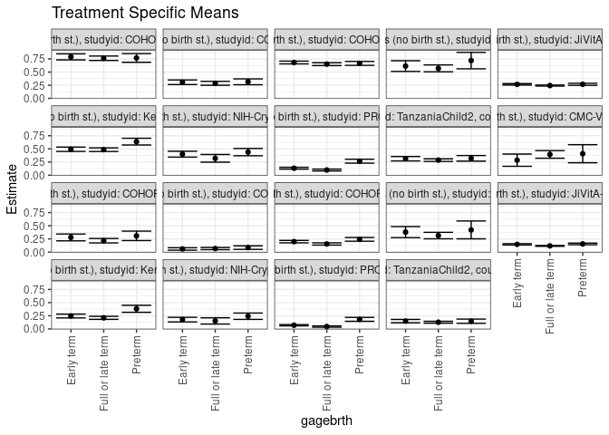

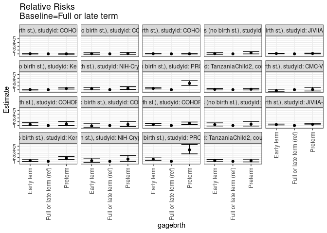

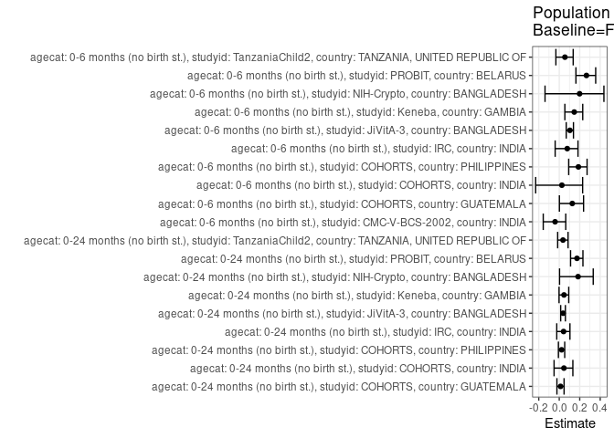

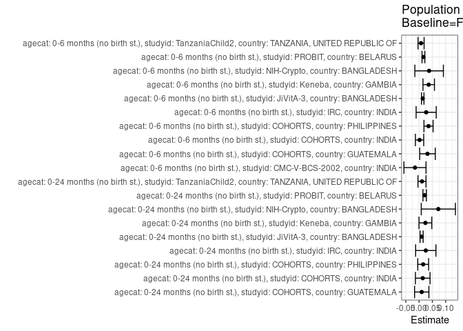

## Results Table

### Parameter: TSM

| agecat | studyid | country | intervention_level | baseline_level | estimate | ci_lower | ci_upper |
| --- | --- | --- | --- | --- | --- | --- | --- |
| 0-24 months (no birth st.) | COHORTS | GUATEMALA | Full or late term | NA | 0.7623862 | 0.7204849 | 0.8042874 |
| 0-24 months (no birth st.) | COHORTS | GUATEMALA | Preterm | NA | 0.7678408 | 0.6857507 | 0.8499310 |
| 0-24 months (no birth st.) | COHORTS | GUATEMALA | Early term | NA | 0.7889175 | 0.7315333 | 0.8463016 |
| 0-24 months (no birth st.) | COHORTS | INDIA | Full or late term | NA | 0.2867650 | 0.2497597 | 0.3237703 |
| 0-24 months (no birth st.) | COHORTS | INDIA | Preterm | NA | 0.3151304 | 0.2596752 | 0.3705855 |
| 0-24 months (no birth st.) | COHORTS | INDIA | Early term | NA | 0.3064696 | 0.2626618 | 0.3502773 |
| 0-24 months (no birth st.) | COHORTS | PHILIPPINES | Full or late term | NA | 0.6508071 | 0.6237647 | 0.6778496 |
| 0-24 months (no birth st.) | COHORTS | PHILIPPINES | Preterm | NA | 0.6650482 | 0.6277507 | 0.7023456 |
| 0-24 months (no birth st.) | COHORTS | PHILIPPINES | Early term | NA | 0.6818882 | 0.6555165 | 0.7082598 |
| 0-24 months (no birth st.) | IRC | INDIA | Full or late term | NA | 0.5701357 | 0.5047709 | 0.6355006 |
| 0-24 months (no birth st.) | IRC | INDIA | Preterm | NA | 0.7187500 | 0.5627423 | 0.8747577 |
| 0-24 months (no birth st.) | IRC | INDIA | Early term | NA | 0.6136364 | 0.5117542 | 0.7155185 |
| 0-24 months (no birth st.) | JiVitA-3 | BANGLADESH | Full or late term | NA | 0.2439132 | 0.2341097 | 0.2537166 |
| 0-24 months (no birth st.) | JiVitA-3 | BANGLADESH | Preterm | NA | 0.2677750 | 0.2481889 | 0.2873611 |
| 0-24 months (no birth st.) | JiVitA-3 | BANGLADESH | Early term | NA | 0.2666707 | 0.2524149 | 0.2809266 |
| 0-24 months (no birth st.) | Keneba | GAMBIA | Full or late term | NA | 0.4854413 | 0.4509735 | 0.5199092 |
| 0-24 months (no birth st.) | Keneba | GAMBIA | Preterm | NA | 0.6381708 | 0.5741598 | 0.7021817 |
| 0-24 months (no birth st.) | Keneba | GAMBIA | Early term | NA | 0.4932611 | 0.4517149 | 0.5348074 |
| 0-24 months (no birth st.) | NIH-Crypto | BANGLADESH | Full or late term | NA | 0.3212309 | 0.2484643 | 0.3939976 |
| 0-24 months (no birth st.) | NIH-Crypto | BANGLADESH | Preterm | NA | 0.4393807 | 0.3705232 | 0.5082382 |
| 0-24 months (no birth st.) | NIH-Crypto | BANGLADESH | Early term | NA | 0.4002731 | 0.3444865 | 0.4560598 |
| 0-24 months (no birth st.) | PROBIT | BELARUS | Full or late term | NA | 0.0996720 | 0.0821091 | 0.1172348 |
| 0-24 months (no birth st.) | PROBIT | BELARUS | Preterm | NA | 0.2668738 | 0.2299286 | 0.3038190 |
| 0-24 months (no birth st.) | PROBIT | BELARUS | Early term | NA | 0.1333817 | 0.1158394 | 0.1509240 |
| 0-24 months (no birth st.) | TanzaniaChild2 | TANZANIA, UNITED REPUBLIC OF | Full or late term | NA | 0.2870423 | 0.2626619 | 0.3114226 |
| 0-24 months (no birth st.) | TanzaniaChild2 | TANZANIA, UNITED REPUBLIC OF | Preterm | NA | 0.3209039 | 0.2680206 | 0.3737872 |
| 0-24 months (no birth st.) | TanzaniaChild2 | TANZANIA, UNITED REPUBLIC OF | Early term | NA | 0.3139230 | 0.2722056 | 0.3556404 |
| 0-6 months (no birth st.) | CMC-V-BCS-2002 | INDIA | Full or late term | NA | 0.3949582 | 0.3230877 | 0.4668287 |
| 0-6 months (no birth st.) | CMC-V-BCS-2002 | INDIA | Preterm | NA | 0.4084874 | 0.2368791 | 0.5800956 |
| 0-6 months (no birth st.) | CMC-V-BCS-2002 | INDIA | Early term | NA | 0.2859488 | 0.1698480 | 0.4020496 |
| 0-6 months (no birth st.) | COHORTS | GUATEMALA | Full or late term | NA | 0.2165124 | 0.1747059 | 0.2583190 |
| 0-6 months (no birth st.) | COHORTS | GUATEMALA | Preterm | NA | 0.3086276 | 0.2188711 | 0.3983842 |
| 0-6 months (no birth st.) | COHORTS | GUATEMALA | Early term | NA | 0.2785291 | 0.2136955 | 0.3433626 |
| 0-6 months (no birth st.) | COHORTS | INDIA | Full or late term | NA | 0.0669705 | 0.0460978 | 0.0878432 |
| 0-6 months (no birth st.) | COHORTS | INDIA | Preterm | NA | 0.0850110 | 0.0514241 | 0.1185979 |
| 0-6 months (no birth st.) | COHORTS | INDIA | Early term | NA | 0.0595124 | 0.0366956 | 0.0823293 |
| 0-6 months (no birth st.) | COHORTS | PHILIPPINES | Full or late term | NA | 0.1542498 | 0.1333489 | 0.1751507 |
| 0-6 months (no birth st.) | COHORTS | PHILIPPINES | Preterm | NA | 0.2417055 | 0.2061046 | 0.2773064 |
| 0-6 months (no birth st.) | COHORTS | PHILIPPINES | Early term | NA | 0.1986299 | 0.1757274 | 0.2215325 |
| 0-6 months (no birth st.) | IRC | INDIA | Full or late term | NA | 0.3135461 | 0.2521440 | 0.3749482 |
| 0-6 months (no birth st.) | IRC | INDIA | Preterm | NA | 0.4210807 | 0.2516780 | 0.5904834 |
| 0-6 months (no birth st.) | IRC | INDIA | Early term | NA | 0.3791305 | 0.2743461 | 0.4839149 |
| 0-6 months (no birth st.) | JiVitA-3 | BANGLADESH | Full or late term | NA | 0.1178601 | 0.1107967 | 0.1249236 |
| 0-6 months (no birth st.) | JiVitA-3 | BANGLADESH | Preterm | NA | 0.1553349 | 0.1399984 | 0.1706713 |
| 0-6 months (no birth st.) | JiVitA-3 | BANGLADESH | Early term | NA | 0.1473787 | 0.1356161 | 0.1591412 |
| 0-6 months (no birth st.) | Keneba | GAMBIA | Full or late term | NA | 0.2105130 | 0.1814617 | 0.2395643 |
| 0-6 months (no birth st.) | Keneba | GAMBIA | Preterm | NA | 0.3823444 | 0.3157196 | 0.4489692 |
| 0-6 months (no birth st.) | Keneba | GAMBIA | Early term | NA | 0.2449553 | 0.2083967 | 0.2815140 |
| 0-6 months (no birth st.) | NIH-Crypto | BANGLADESH | Full or late term | NA | 0.1521580 | 0.0930434 | 0.2112725 |
| 0-6 months (no birth st.) | NIH-Crypto | BANGLADESH | Preterm | NA | 0.2413352 | 0.1811685 | 0.3015018 |
| 0-6 months (no birth st.) | NIH-Crypto | BANGLADESH | Early term | NA | 0.1764353 | 0.1327433 | 0.2201274 |
| 0-6 months (no birth st.) | PROBIT | BELARUS | Full or late term | NA | 0.0451187 | 0.0332801 | 0.0569573 |
| 0-6 months (no birth st.) | PROBIT | BELARUS | Preterm | NA | 0.1819442 | 0.1447632 | 0.2191253 |
| 0-6 months (no birth st.) | PROBIT | BELARUS | Early term | NA | 0.0702976 | 0.0579627 | 0.0826325 |
| 0-6 months (no birth st.) | TanzaniaChild2 | TANZANIA, UNITED REPUBLIC OF | Full or late term | NA | 0.1272303 | 0.1092931 | 0.1451675 |
| 0-6 months (no birth st.) | TanzaniaChild2 | TANZANIA, UNITED REPUBLIC OF | Preterm | NA | 0.1463304 | 0.1062647 | 0.1863960 |
| 0-6 months (no birth st.) | TanzaniaChild2 | TANZANIA, UNITED REPUBLIC OF | Early term | NA | 0.1483911 | 0.1163703 | 0.1804119 |

### Parameter: E(Y)

| agecat | studyid | country | intervention_level | baseline_level | estimate | ci_lower | ci_upper |
| --- | --- | --- | --- | --- | --- | --- | --- |
| 0-24 months (no birth st.) | COHORTS | GUATEMALA | NA | NA | 0.7723343 | 0.7411143 | 0.8035543 |
| 0-24 months (no birth st.) | COHORTS | INDIA | NA | NA | 0.3004847 | 0.2749357 | 0.3260336 |
| 0-24 months (no birth st.) | COHORTS | PHILIPPINES | NA | NA | 0.6661982 | 0.6488700 | 0.6835264 |
| 0-24 months (no birth st.) | IRC | INDIA | NA | NA | 0.5953079 | 0.5431354 | 0.6474804 |
| 0-24 months (no birth st.) | JiVitA-3 | BANGLADESH | NA | NA | 0.2533685 | 0.2454041 | 0.2613329 |
| 0-24 months (no birth st.) | Keneba | GAMBIA | NA | NA | 0.5091714 | 0.4845214 | 0.5338214 |
| 0-24 months (no birth st.) | NIH-Crypto | BANGLADESH | NA | NA | 0.3935681 | 0.3560687 | 0.4310676 |
| 0-24 months (no birth st.) | PROBIT | BELARUS | NA | NA | 0.1205488 | 0.1047261 | 0.1363714 |
| 0-24 months (no birth st.) | TanzaniaChild2 | TANZANIA, UNITED REPUBLIC OF | NA | NA | 0.2979534 | 0.2783922 | 0.3175146 |
| 0-6 months (no birth st.) | CMC-V-BCS-2002 | INDIA | NA | NA | 0.3795620 | 0.3219972 | 0.4371269 |
| 0-6 months (no birth st.) | COHORTS | GUATEMALA | NA | NA | 0.2481315 | 0.2153770 | 0.2808861 |
| 0-6 months (no birth st.) | COHORTS | INDIA | NA | NA | 0.0687398 | 0.0545482 | 0.0829313 |
| 0-6 months (no birth st.) | COHORTS | PHILIPPINES | NA | NA | 0.1897400 | 0.1753322 | 0.2041478 |
| 0-6 months (no birth st.) | IRC | INDIA | NA | NA | 0.3401760 | 0.2898173 | 0.3905347 |
| 0-6 months (no birth st.) | JiVitA-3 | BANGLADESH | NA | NA | 0.1315668 | 0.1257634 | 0.1373703 |
| 0-6 months (no birth st.) | Keneba | GAMBIA | NA | NA | 0.2466667 | 0.2248446 | 0.2684887 |
| 0-6 months (no birth st.) | NIH-Crypto | BANGLADESH | NA | NA | 0.1898928 | 0.1597870 | 0.2199986 |
| 0-6 months (no birth st.) | PROBIT | BELARUS | NA | NA | 0.0614448 | 0.0507274 | 0.0721623 |
| 0-6 months (no birth st.) | TanzaniaChild2 | TANZANIA, UNITED REPUBLIC OF | NA | NA | 0.1346978 | 0.1200961 | 0.1492994 |

### Parameter: RR

| agecat | studyid | country | intervention_level | baseline_level | estimate | ci_lower | ci_upper |
| --- | --- | --- | --- | --- | --- | --- | --- |
| 0-24 months (no birth st.) | COHORTS | GUATEMALA | Full or late term | Full or late term | 1.0000000 | 1.0000000 | 1.000000 |
| 0-24 months (no birth st.) | COHORTS | GUATEMALA | Preterm | Full or late term | 1.0071548 | 0.8931086 | 1.135764 |
| 0-24 months (no birth st.) | COHORTS | GUATEMALA | Early term | Full or late term | 1.0348003 | 0.9446022 | 1.133611 |
| 0-24 months (no birth st.) | COHORTS | INDIA | Full or late term | Full or late term | 1.0000000 | 1.0000000 | 1.000000 |
| 0-24 months (no birth st.) | COHORTS | INDIA | Preterm | Full or late term | 1.0989150 | 0.8849458 | 1.364619 |
| 0-24 months (no birth st.) | COHORTS | INDIA | Early term | Full or late term | 1.0687133 | 0.8833590 | 1.292960 |
| 0-24 months (no birth st.) | COHORTS | PHILIPPINES | Full or late term | Full or late term | 1.0000000 | 1.0000000 | 1.000000 |
| 0-24 months (no birth st.) | COHORTS | PHILIPPINES | Preterm | Full or late term | 1.0218821 | 0.9538606 | 1.094754 |
| 0-24 months (no birth st.) | COHORTS | PHILIPPINES | Early term | Full or late term | 1.0477577 | 0.9909554 | 1.107816 |
| 0-24 months (no birth st.) | IRC | INDIA | Full or late term | Full or late term | 1.0000000 | 1.0000000 | 1.000000 |
| 0-24 months (no birth st.) | IRC | INDIA | Preterm | Full or late term | 1.2606647 | 0.9862620 | 1.611413 |
| 0-24 months (no birth st.) | IRC | INDIA | Early term | Full or late term | 1.0762987 | 0.8796426 | 1.316920 |
| 0-24 months (no birth st.) | JiVitA-3 | BANGLADESH | Full or late term | Full or late term | 1.0000000 | 1.0000000 | 1.000000 |
| 0-24 months (no birth st.) | JiVitA-3 | BANGLADESH | Preterm | Full or late term | 1.0978290 | 1.0120082 | 1.190927 |
| 0-24 months (no birth st.) | JiVitA-3 | BANGLADESH | Early term | Full or late term | 1.0933018 | 1.0267497 | 1.164168 |
| 0-24 months (no birth st.) | Keneba | GAMBIA | Full or late term | Full or late term | 1.0000000 | 1.0000000 | 1.000000 |
| 0-24 months (no birth st.) | Keneba | GAMBIA | Preterm | Full or late term | 1.3146198 | 1.1630139 | 1.485988 |
| 0-24 months (no birth st.) | Keneba | GAMBIA | Early term | Full or late term | 1.0161087 | 0.9103550 | 1.134147 |
| 0-24 months (no birth st.) | NIH-Crypto | BANGLADESH | Full or late term | Full or late term | 1.0000000 | 1.0000000 | 1.000000 |
| 0-24 months (no birth st.) | NIH-Crypto | BANGLADESH | Preterm | Full or late term | 1.3678033 | 1.0397943 | 1.799284 |
| 0-24 months (no birth st.) | NIH-Crypto | BANGLADESH | Early term | Full or late term | 1.2460604 | 0.9565745 | 1.623153 |
| 0-24 months (no birth st.) | PROBIT | BELARUS | Full or late term | Full or late term | 1.0000000 | 1.0000000 | 1.000000 |
| 0-24 months (no birth st.) | PROBIT | BELARUS | Preterm | Full or late term | 2.6775213 | 2.1281084 | 3.368776 |
| 0-24 months (no birth st.) | PROBIT | BELARUS | Early term | Full or late term | 1.3382065 | 1.1927530 | 1.501398 |
| 0-24 months (no birth st.) | TanzaniaChild2 | TANZANIA, UNITED REPUBLIC OF | Full or late term | Full or late term | 1.0000000 | 1.0000000 | 1.000000 |
| 0-24 months (no birth st.) | TanzaniaChild2 | TANZANIA, UNITED REPUBLIC OF | Preterm | Full or late term | 1.1179674 | 0.9287550 | 1.345728 |
| 0-24 months (no birth st.) | TanzaniaChild2 | TANZANIA, UNITED REPUBLIC OF | Early term | Full or late term | 1.0936472 | 0.9341263 | 1.280409 |
| 0-6 months (no birth st.) | CMC-V-BCS-2002 | INDIA | Full or late term | Full or late term | 1.0000000 | 1.0000000 | 1.000000 |
| 0-6 months (no birth st.) | CMC-V-BCS-2002 | INDIA | Preterm | Full or late term | 1.0342546 | 0.6542490 | 1.634978 |
| 0-6 months (no birth st.) | CMC-V-BCS-2002 | INDIA | Early term | Full or late term | 0.7239976 | 0.4638600 | 1.130023 |
| 0-6 months (no birth st.) | COHORTS | GUATEMALA | Full or late term | Full or late term | 1.0000000 | 1.0000000 | 1.000000 |
| 0-6 months (no birth st.) | COHORTS | GUATEMALA | Preterm | Full or late term | 1.4254499 | 1.0050930 | 2.021611 |
| 0-6 months (no birth st.) | COHORTS | GUATEMALA | Early term | Full or late term | 1.2864345 | 0.9504669 | 1.741159 |
| 0-6 months (no birth st.) | COHORTS | INDIA | Full or late term | Full or late term | 1.0000000 | 1.0000000 | 1.000000 |
| 0-6 months (no birth st.) | COHORTS | INDIA | Preterm | Full or late term | 1.2693799 | 0.7678735 | 2.098426 |
| 0-6 months (no birth st.) | COHORTS | INDIA | Early term | Full or late term | 0.8886368 | 0.5424524 | 1.455750 |
| 0-6 months (no birth st.) | COHORTS | PHILIPPINES | Full or late term | Full or late term | 1.0000000 | 1.0000000 | 1.000000 |
| 0-6 months (no birth st.) | COHORTS | PHILIPPINES | Preterm | Full or late term | 1.5669746 | 1.2832605 | 1.913415 |
| 0-6 months (no birth st.) | COHORTS | PHILIPPINES | Early term | Full or late term | 1.2877158 | 1.0784353 | 1.537609 |
| 0-6 months (no birth st.) | IRC | INDIA | Full or late term | Full or late term | 1.0000000 | 1.0000000 | 1.000000 |
| 0-6 months (no birth st.) | IRC | INDIA | Preterm | Full or late term | 1.3429625 | 0.8590061 | 2.099575 |
| 0-6 months (no birth st.) | IRC | INDIA | Early term | Full or late term | 1.2091698 | 0.8615115 | 1.697124 |
| 0-6 months (no birth st.) | JiVitA-3 | BANGLADESH | Full or late term | Full or late term | 1.0000000 | 1.0000000 | 1.000000 |
| 0-6 months (no birth st.) | JiVitA-3 | BANGLADESH | Preterm | Full or late term | 1.3179596 | 1.1763466 | 1.476621 |
| 0-6 months (no birth st.) | JiVitA-3 | BANGLADESH | Early term | Full or late term | 1.2504542 | 1.1339307 | 1.378952 |
| 0-6 months (no birth st.) | Keneba | GAMBIA | Full or late term | Full or late term | 1.0000000 | 1.0000000 | 1.000000 |
| 0-6 months (no birth st.) | Keneba | GAMBIA | Preterm | Full or late term | 1.8162509 | 1.4543959 | 2.268136 |
| 0-6 months (no birth st.) | Keneba | GAMBIA | Early term | Full or late term | 1.1636115 | 0.9497389 | 1.425646 |
| 0-6 months (no birth st.) | NIH-Crypto | BANGLADESH | Full or late term | Full or late term | 1.0000000 | 1.0000000 | 1.000000 |
| 0-6 months (no birth st.) | NIH-Crypto | BANGLADESH | Preterm | Full or late term | 1.5860829 | 0.9995005 | 2.516916 |
| 0-6 months (no birth st.) | NIH-Crypto | BANGLADESH | Early term | Full or late term | 1.1595538 | 0.7316337 | 1.837757 |
| 0-6 months (no birth st.) | PROBIT | BELARUS | Full or late term | Full or late term | 1.0000000 | 1.0000000 | 1.000000 |
| 0-6 months (no birth st.) | PROBIT | BELARUS | Preterm | Full or late term | 4.0325682 | 2.9791847 | 5.458408 |
| 0-6 months (no birth st.) | PROBIT | BELARUS | Early term | Full or late term | 1.5580584 | 1.2754682 | 1.903259 |
| 0-6 months (no birth st.) | TanzaniaChild2 | TANZANIA, UNITED REPUBLIC OF | Full or late term | Full or late term | 1.0000000 | 1.0000000 | 1.000000 |
| 0-6 months (no birth st.) | TanzaniaChild2 | TANZANIA, UNITED REPUBLIC OF | Preterm | Full or late term | 1.1501222 | 0.8453222 | 1.564825 |
| 0-6 months (no birth st.) | TanzaniaChild2 | TANZANIA, UNITED REPUBLIC OF | Early term | Full or late term | 1.1663191 | 0.9012881 | 1.509285 |

### Parameter: PAR

| agecat | studyid | country | intervention_level | baseline_level | estimate | ci_lower | ci_upper |
| --- | --- | --- | --- | --- | --- | --- | --- |
| 0-24 months (no birth st.) | COHORTS | GUATEMALA | Full or late term | NA | 0.0099481 | -0.0169631 | 0.0368594 |
| 0-24 months (no birth st.) | COHORTS | INDIA | Full or late term | NA | 0.0137197 | -0.0138158 | 0.0412551 |
| 0-24 months (no birth st.) | COHORTS | PHILIPPINES | Full or late term | NA | 0.0153910 | -0.0050985 | 0.0358806 |
| 0-24 months (no birth st.) | IRC | INDIA | Full or late term | NA | 0.0251722 | -0.0129918 | 0.0633362 |
| 0-24 months (no birth st.) | JiVitA-3 | BANGLADESH | Full or late term | NA | 0.0094553 | 0.0036468 | 0.0152638 |
| 0-24 months (no birth st.) | Keneba | GAMBIA | Full or late term | NA | 0.0237301 | -0.0003425 | 0.0478027 |
| 0-24 months (no birth st.) | NIH-Crypto | BANGLADESH | Full or late term | NA | 0.0723372 | 0.0081014 | 0.1365730 |
| 0-24 months (no birth st.) | PROBIT | BELARUS | Full or late term | NA | 0.0208768 | 0.0143489 | 0.0274047 |
| 0-24 months (no birth st.) | TanzaniaChild2 | TANZANIA, UNITED REPUBLIC OF | Full or late term | NA | 0.0109111 | -0.0042131 | 0.0260353 |
| 0-6 months (no birth st.) | CMC-V-BCS-2002 | INDIA | Full or late term | NA | -0.0153962 | -0.0570165 | 0.0262241 |
| 0-6 months (no birth st.) | COHORTS | GUATEMALA | Full or late term | NA | 0.0316191 | 0.0023099 | 0.0609284 |
| 0-6 months (no birth st.) | COHORTS | INDIA | Full or late term | NA | 0.0017693 | -0.0138555 | 0.0173940 |
| 0-6 months (no birth st.) | COHORTS | PHILIPPINES | Full or late term | NA | 0.0354902 | 0.0183545 | 0.0526259 |
| 0-6 months (no birth st.) | IRC | INDIA | Full or late term | NA | 0.0266298 | -0.0111883 | 0.0644480 |
| 0-6 months (no birth st.) | JiVitA-3 | BANGLADESH | Full or late term | NA | 0.0137067 | 0.0090389 | 0.0183746 |
| 0-6 months (no birth st.) | Keneba | GAMBIA | Full or late term | NA | 0.0361537 | 0.0145621 | 0.0577453 |
| 0-6 months (no birth st.) | NIH-Crypto | BANGLADESH | Full or late term | NA | 0.0377348 | -0.0159594 | 0.0914290 |
| 0-6 months (no birth st.) | PROBIT | BELARUS | Full or late term | NA | 0.0163261 | 0.0110921 | 0.0215602 |
| 0-6 months (no birth st.) | TanzaniaChild2 | TANZANIA, UNITED REPUBLIC OF | Full or late term | NA | 0.0074675 | -0.0039168 | 0.0188518 |

### Parameter: PAF

| agecat | studyid | country | intervention_level | baseline_level | estimate | ci_lower | ci_upper |
| --- | --- | --- | --- | --- | --- | --- | --- |
| 0-24 months (no birth st.) | COHORTS | GUATEMALA | Full or late term | NA | 0.0128806 | -0.0226080 | 0.0471376 |
| 0-24 months (no birth st.) | COHORTS | INDIA | Full or late term | NA | 0.0456584 | -0.0504864 | 0.1330037 |
| 0-24 months (no birth st.) | COHORTS | PHILIPPINES | Full or late term | NA | 0.0231028 | -0.0081582 | 0.0533945 |
| 0-24 months (no birth st.) | IRC | INDIA | Full or late term | NA | 0.0422843 | -0.0242259 | 0.1044755 |
| 0-24 months (no birth st.) | JiVitA-3 | BANGLADESH | Full or late term | NA | 0.0373184 | 0.0141011 | 0.0599889 |
| 0-24 months (no birth st.) | Keneba | GAMBIA | Full or late term | NA | 0.0466053 | -0.0019229 | 0.0927830 |
| 0-24 months (no birth st.) | NIH-Crypto | BANGLADESH | Full or late term | NA | 0.1837985 | 0.0030283 | 0.3317916 |
| 0-24 months (no birth st.) | PROBIT | BELARUS | Full or late term | NA | 0.1731813 | 0.1106501 | 0.2313159 |
| 0-24 months (no birth st.) | TanzaniaChild2 | TANZANIA, UNITED REPUBLIC OF | Full or late term | NA | 0.0366201 | -0.0154885 | 0.0860548 |
| 0-6 months (no birth st.) | CMC-V-BCS-2002 | INDIA | Full or late term | NA | -0.0405630 | -0.1562239 | 0.0635280 |
| 0-6 months (no birth st.) | COHORTS | GUATEMALA | Full or late term | NA | 0.1274288 | 0.0014169 | 0.2375392 |
| 0-6 months (no birth st.) | COHORTS | INDIA | Full or late term | NA | 0.0257387 | -0.2301969 | 0.2284283 |
| 0-6 months (no birth st.) | COHORTS | PHILIPPINES | Full or late term | NA | 0.1870464 | 0.0923516 | 0.2718617 |
| 0-6 months (no birth st.) | IRC | INDIA | Full or late term | NA | 0.0782825 | -0.0398809 | 0.1830189 |
| 0-6 months (no birth st.) | JiVitA-3 | BANGLADESH | Full or late term | NA | 0.1041808 | 0.0681726 | 0.1387976 |
| 0-6 months (no birth st.) | Keneba | GAMBIA | Full or late term | NA | 0.1465689 | 0.0548262 | 0.2294067 |
| 0-6 months (no birth st.) | NIH-Crypto | BANGLADESH | Full or late term | NA | 0.1987165 | -0.1387662 | 0.4361834 |
| 0-6 months (no birth st.) | PROBIT | BELARUS | Full or late term | NA | 0.2657040 | 0.1629111 | 0.3558742 |
| 0-6 months (no birth st.) | TanzaniaChild2 | TANZANIA, UNITED REPUBLIC OF | Full or late term | NA | 0.0554387 | -0.0327923 | 0.1361322 |